# *"Who Told You What to Believe?"*

### Deconstructing the Social Blueprint of Political Identity through Machine Learning

## MACHINE LEARNING FINAL PROJECT

In partial fulfillment of the requirements for the subject Machine Learning

## 1. Executive Summary

This project investigates the complex social factors shaping political identity, focusing on the relative influence of family and peer groups. Utilizing a comprehensive survey and advanced machine learning techniques, the study analyzes how various social interaction elements—such as frequency of political discussions, emotional tone, social approval, and perceived pressure—contribute to an individual’s political alignment.

Through classification models including Random Forest, AdaBoost, Logistic Regression, and Linear SVM, the research identifies which social context, family or peers, predominantly influences political beliefs. Random Forest achieved the highest predictive accuracy, while Logistic Regression and Linear SVM demonstrated strong generalizability due to minimal overfitting. AdaBoost also showed promising results by effectively capturing nuanced social patterns.

The findings underscore that political identity is not formed in isolation but is a dynamic outcome of ongoing social engagement with family and peers. This highlights the importance of understanding political socialization as a social process, where approval, discussion, and reflection within these groups shape political views.

Survey questions were carefully chosen and validated based on established political socialization theories, ensuring that key dimensions of social influence and individual demographics were effectively captured. The study’s insights can inform tailored civic education initiatives and community programs aimed at promoting critical political thinking and independent political identities.

Overall, this research bridges theoretical perspectives with data-driven methods to deepen our understanding of the social blueprint behind political identity formation, with practical implications for enhancing political engagement and social cohesion.

## 2. Introduction

The formation of political identity is a complex process influenced by various social agents, with family and peers often cited as primary drivers of individual belief systems. This project examines the relative impact of these two key social contexts on shaping political alignment. While prior research acknowledges the significant role of socialization in political development (Jennings & Niemi, 1968; Beck & Jennings, 1991), there remains a need to quantitatively deconstruct the multifaceted dimensions of influence and their differential effects.

Drawing on theoretical frameworks from political socialization theory, social identity theory (Tajfel & Turner, 1979), and research on group conformity (Asch, 1955), this study posits that political beliefs are not formed in isolation but are, instead, the result of intricate social dynamics. Specifically, we investigate how the frequency of political discussions, the emotional tone of those interactions, perceived social pressure, and the salience of social approval within family and peer groups collectively shape individual political orientation.

To empirically assess these dynamics, we employ machine learning techniques to analyze a comprehensive survey dataset. This approach allows us to classify individuals based on whether their political alignment is more strongly influenced by family or peer contexts, considering a range of predictor variables that capture both direct and indirect dimensions of social influence.

The primary objective of this project is to move beyond descriptive accounts of political socialization and provide a quantitative, predictive model of how social contexts shape political identity. By uncovering the nuanced interplay of these influences, this research contributes to a more granular understanding of political behavior and informs discussions on political engagement, social cohesion, and the development of independent political thought.

## 3. Problem Statement

Despite extensive research acknowledging the importance of socialization in political identity formation, there remains a significant gap in understanding the relative influence of family versus peers on an individual’s political alignment. Traditional studies often treat these influences in isolation or rely on qualitative assessments, limiting the ability to systematically quantify and classify their impact. This lack of clarity hinders our capacity to comprehend how social environments shape political beliefs, especially in an era where social networks and peer groups have become increasingly diverse and influential.

The problem this project addresses is: How can we accurately identify whether a person’s political alignment is primarily influenced by family or peers, using multidimensional social and psychological factors? Furthermore, it seeks to explore which specific aspects of social interaction—such as discussion frequency, emotional tone, social pressure, and approval importance—serve as the strongest predictors of political influence from these groups.

By leveraging machine learning techniques on comprehensive survey data, this study aims to fill this gap by providing a robust, data-driven classification model. The results will enhance our understanding of the social blueprint underlying political identity and contribute to more effective strategies for fostering independent political thought and engagement.

## 3.1 Objectives

To identify and quantify the relative influence of family and peers on an individual’s political alignment using survey data.

1. **To analyze the role of social interaction factors**—such as frequency of political discussions, emotional tone, perceived social pressure, and importance of social approval—in shaping political beliefs within family and peer contexts.
2. **To develop and validate a machine learning classification model** that predicts whether a person’s political alignment is primarily influenced by family or peers based on multidimensional social and psychological variables.
3. **To examine demographic and individual factors** (e.g., age, gender, educational level, personal confidence) that moderate the strength of family and peer influence on political identity.
4. **To contribute empirical insights into the social mechanisms** underlying political identity formation, informing strategies to promote critical political self-reflection and independent political thought.

## 4. Methodology

# Detailed Methodology Summary

[figure not shown]

### 1. Data Acquisition

- We collected original data through surveys distributed both online and offline (paper-based).
- These surveys targeted individuals considered to be within the youth demographic, conducted inside and outside the university.
- The data gathered was carefully selected to align with the study's objectives.

### 2. Data Preprocessing

- Data cleaning involved removing inconsistencies, missing values, and erroneous entries.
- Data transformation included normalization or scaling of variables to prepare for modeling.
- Feature selection was applied to identify the most relevant predictors.

### 3. Exploratory Data Analysis (EDA)

- Visual and statistical methods were employed to understand data distributions, detect outliers, and identify patterns or correlations.
- Summary statistics and plots helped gain insights into the dataset.

### 4. Model Development

- Several machine learning models were developed, including baseline and more complex algorithms.
- The dataset was split into training and testing sets, commonly at an 80%-20% ratio.
- Cross-validation techniques ensured model robustness.
- Hyperparameter tuning optimized model performance.

### 5. Model Evaluation

- Evaluation metrics such as accuracy, precision, recall, F1 score, and confusion matrices were calculated.
- Feature importance analyses were conducted to interpret model decisions.
- Model explainability tools (e.g., SHAP values) provided deeper insights.

### 6. Results and Deployment

- The best performing model was selected based on evaluation metrics.
- Results were compiled and documented in the report.
- Potential deployment or application areas were discussed.

### 4.1 Data Collection

The dataset used in this study was gathered through a carefully designed survey targeting youth populations both within and outside the university community. This mixed-method approach combined **online surveys** and **paper-based questionnaires** to ensure wider reach and inclusion of participants with varying access to technology.

### Survey Design and Distribution

The survey was disseminated via two primary channels:

- **Online Surveys:** Shared through university mailing lists, social media groups, and youth-oriented forums, allowing convenient and timely data collection from tech-savvy respondents.
- **Offline Paper Surveys:** Distributed in-person within the university premises and nearby community centers to include participants with limited internet access or preference for physical questionnaires.

Before any preprocessing or cleaning, our dataset consisted of **723 entries** with **39 columns** representing survey responses from youth participants inside and outside the university. Below is a summary of the dataset structure:

| Feature Count | 723 entries (0 to 722) |
| --- | --- |
| Columns | 39 |
| Data Types | 34 object, 3 int64, 2 float64 |

Many columns correspond to answers from specific survey questions. Below is a breakdown of the types of variables collected:

### Ordinal Columns

These columns represent responses on an ordered scale, reflecting intensity or frequency:

| Column | Possible Responses |
| --- | --- |
| FamilyDiscussionInterest | not at all, rarely, sometimes, often, very well |
| PeerDiscussionInterest | not at all, rarely, sometimes, often, very well |
| FamilyInfluenceStrength | none, slight, moderate, strong |
| PeerInfluenceStrength | none, slight, moderate, strong |
| PersonalIndentityStrength | weak, moderate, strong |
| ParentApprovalLevel | strongly disagree, disagree, neutral, agree, strongly agree |
| PeerApprovalLevel | strongly disagree, disagree, neutral, agree, strongly agree |
| PersonalConfidenceLevel | low, medium, high |
| political_self_reflection_freq_family | never, rarely, sometimes, often, always |
| political_self_reflection_freq_peers | never, rarely, sometimes, often, always |
| family_approval_importance_politics | not at all, a little, somewhat, very much, absolutely |
| peer_approval_importance_politics | not at all, a little, somewhat, very much, absolutely |
| political_identity_conflict | never, rarely, sometimes, often, always |
| importance_fam_political_alignment | not important, slightly important, moderately important, very important, extremely important |
| importance_peer_political_alignment | not important, slightly important, moderately important, very important, extremely important |

### Nominal Columns

These columns represent categorical data without intrinsic ordering, often yes/no or descriptive answers:

- gender
- educational_level
- OwnPoliticalView
- FamilyPoliticalView
- PeerPoliticalView
- ListenToFamilyDiscussion
- ListenToPeerDiscussion
- FamilyEmotionalTone
- PeerEmotionalTone
- family_attempt_political_influence
- peer_attempt_political_influence
- age_political_awareness_onset
- FamilyPressure
- PeerPressure
- Political_Alignment

### Dataset Feature Explanation Table :

| Feature Name | Corresponding Question | Description & Relevance |
| --- | --- | --- |
| gender | What is your gender? | Demographic variable to analyze political views and influences by gender. |
| age | How old are you? | Age is key to understand developmental differences in political identity and awareness onset. |
| educational_level | What is your highest educational attainment? | Education level can influence political awareness and opinion formation. |
| OwnPoliticalView | What is your own political view? | Captures personal political stance, central to understanding identity. |
| FamilyPoliticalView | What is your family's political view? | Family views often influence an individual’s political alignment. |
| PeerPoliticalView | What is the political view of your peers? | Peer influence plays a major role in youth political identity formation. |
| ListenToFamilyDiscussion | Do you listen to family political discussions? | Measures exposure to family political dialogue, affecting influence strength. |
| ListenToPeerDiscussion | Do you listen to political discussions among peers? | Measures exposure to peer political discussions. |
| FamilyDiscussionInterest | How interested are you in family political discussions? | Gauges engagement level with family politics. |
| PeerDiscussionInterest | How interested are you in peer political discussions? | Gauges engagement level with peer political discussions. |
| FamilyInfluenceStrength | How strong is your family’s influence on your politics? | Captures subjective perception of family political influence strength. |
| PeerInfluenceStrength | How strong is your peers’ influence on your politics? | Captures subjective perception of peer political influence strength. |
| FamilyEmotionalTone | What is the emotional tone of family political discussions? | Provides context on the quality of family political engagement. |
| PeerEmotionalTone | What is the emotional tone of peer political discussions? | Provides context on the quality of peer political engagement. |
| FamilyEngagement | Numeric measure of family engagement | Quantifies family involvement in political socialization. |
| PeerEngagement | Numeric measure of peer engagement | Quantifies peer involvement in political socialization. |
| PersonalIndentityStrength | How strong do you feel your political identity is? | Measures political identity strength, crucial for understanding self-concept development. |
| ParentApprovalLevel | Level of agreement with parents on political views | Reflects the extent of political approval or conflict with parents. |
| PeerApprovalLevel | Level of agreement with peers on political views | Reflects the extent of political approval or conflict with peers. |
| PersonalConfidenceLevel | How confident are you about your political views? | Indicates certainty and stability in political beliefs. |
| PoliticalIssues | What political issues do you care about? | Captures topical interests shaping political attitudes. |
| political_self_reflection_freq_family | Frequency of political self-reflection influenced by family | Indicates introspective engagement influenced by family context. |
| political_self_reflection_freq_peers | Frequency of political self-reflection influenced by peers | Indicates introspective engagement influenced by peer context. |
| family_attempt_political_influence | Has family tried to influence your political views? | Measures direct political influence attempts by family. |
| peer_attempt_political_influence | Has peer group tried to influence your political views? | Measures direct political influence attempts by peers. |
| age_political_awareness_onset | At what age did you become politically aware? | Helps correlate political awareness timing with social influences. |
| family_approval_importance_politics | How important is family approval in your politics? | Captures value placed on family’s political acceptance. |
| peer_approval_importance_politics | How important is peer approval in your politics? | Captures value placed on peer group’s political acceptance. |
| FamilyPressure | Do you feel political pressure from your family? | Measures perceived political pressure from family. |
| PeerPressure | Do you feel political pressure from your peers? | Measures perceived political pressure from peers. |
| political_identity_conflict | Frequency of conflicts regarding your political identity | Gauges internal/external conflicts related to political self-concept. |
| importance_fam_political_alignment | How important is political alignment with family? | Measures importance of shared political views with family. |
| importance_peer_political_alignment | How important is political alignment with peers? | Measures importance of shared political views with peers. |
| Political_Alignment | What is your overall political alignment? | The main target variable representing overall political stance. |

This detailed feature explanation contextualizes each survey question and highlights its relevance to the study of youth political identity and social influences.

### 4.2 Data Cleaning

```python
# --------------------
#    Data Handling
# --------------------
import pandas as pd
import numpy as np
from collections import Counter
from sklearn.base import clone

# --------------------
#    Data Visualization
# --------------------
import seaborn as sns
import matplotlib.pyplot as plt
from wordcloud import WordCloud
from tqdm import tqdm  # Progress bar for loops and tasks visualization

# --------------------
#    Text Preprocessing & NLP
# --------------------
import re
import nltk
from nltk.tokenize import word_tokenize
from nltk.corpus import stopwords
from nltk.stem import WordNetLemmatizer
import spacy
from textblob import TextBlob
from symspellpy import SymSpell
from rake_nltk import Rake
from keybert import KeyBERT
from sklearn.preprocessing import OrdinalEncoder, OneHotEncoder

# --------------------
#    Feature Engineering & Extraction
# --------------------
from sklearn.preprocessing import LabelEncoder, OneHotEncoder, MultiLabelBinarizer, StandardScaler
from sklearn.feature_extraction.text import TfidfVectorizer
from sklearn.compose import ColumnTransformer

# --------------------
#    Model Selection & Evaluation
# --------------------
from sklearn.model_selection import train_test_split, GridSearchCV, RandomizedSearchCV
from sklearn.metrics import accuracy_score
from sklearn.pipeline import make_pipeline
from sklearn.model_selection import KFold, StratifiedKFold, cross_val_score, cross_val_predict, cross_validate
from sklearn.pipeline import Pipeline
from sklearn.model_selection import GridSearchCV

# --------------------
#    Machine Learning Models
# --------------------
from sklearn.neighbors import KNeighborsClassifier
from sklearn.tree import DecisionTreeClassifier
from sklearn.ensemble import RandomForestClassifier, GradientBoostingClassifier
from sklearn.linear_model import LogisticRegression
from sklearn.svm import LinearSVC

# Suppress warnings
import warnings
warnings.filterwarnings('ignore')
```

```python
# ------------------------
#  Load the datasets
# -------------------------


online  = pd.read_csv('online_responses.csv')
offline = pd.read_csv('offline_responses.csv')
```

```python
# Combine and fill missing columns with NaN (if one dataset has columns the other lacks)
data = pd.concat([online, offline], axis=0, ignore_index=True, sort=False)
```

```python
data.info()
```

```
<class 'pandas.core.frame.DataFrame'>
RangeIndex: 723 entries, 0 to 722
Data columns (total 39 columns):
 #   Column                                 Non-Null Count  Dtype
---  ------                                 --------------  -----
 0   timestamp                              643 non-null    object
 1   consent                                253 non-null    object
 2   name                                   213 non-null    object
 3   gender                                 723 non-null    object
 4   age                                    723 non-null    int64
 5   educational_level                      723 non-null    object
 6   OwnPoliticalView                       723 non-null    object
 7   FamilyPoliticalView                    723 non-null    object
 8   PeerPoliticalView                      723 non-null    object
 9   ListenToFamilyDiscussion               723 non-null    object
```

[output cut: 31 more lines]

```python
data.describe()
```

|  | age | FamilyEngagement | PeerEngagement | Column 38 | Column 39 |
| --- | --- | --- | --- | --- | --- |
| count | 723.000000 | 723.000000 | 723.000000 | 0.0 | 0.0 |
| mean | 21.085754 | 1.962656 | 2.077455 | NaN | NaN |
| std | 7.750854 | 1.270806 | 1.281480 | NaN | NaN |
| min | 13.000000 | 0.000000 | 0.000000 | NaN | NaN |
| 25% | 19.000000 | 1.000000 | 1.000000 | NaN | NaN |
| 50% | 20.000000 | 2.000000 | 2.000000 | NaN | NaN |
| 75% | 22.000000 | 3.000000 | 3.000000 | NaN | NaN |
| max | 212.000000 | 5.000000 | 5.000000 | NaN | NaN |

```python
data.describe(include=object)
```

|  | timestamp | consent | name | gender | educational_level | OwnPoliticalView | FamilyPoliticalView | PeerPoliticalView | ListenToFamilyDiscussion | ListenToPeerDiscussion | ... | peer_attempt_political_influence | age_political_awareness_onset | family_approval_importance_politics | peer_approval_importance_politics | FamilyPressure | PeerPressure | political_identity_conflict | importance_fam_political_alignment | importance_peer_political_alignment | Political_Alignment |
| --- | --- | --- | --- | --- | --- | --- | --- | --- | --- | --- | --- | --- | --- | --- | --- | --- | --- | --- | --- | --- | --- |
| count | 643 | 253 | 213 | 723 | 723 | 723 | 723 | 723 | 723 | 723 | ... | 722 | 722 | 723 | 723 | 723 | 723 | 723 | 723 | 722 | 723 |
| unique | 243 | 1 | 211 | 11 | 4 | 6 | 7 | 7 | 5 | 5 | ... | 4 | 7 | 11 | 14 | 6 | 3 | 11 | 13 | 10 | 4 |
| top | 5/8/2025 | Yes, I consent | Mary | F | College | Liberal | Conservative | Liberal | Yes | Yes | ... | Yes | Teen Years | Somewhat | Somewhat | No | No | Sometimes | Very Important | Moderately Important | Family |
| freq | 135 | 253 | 2 | 185 | 612 | 452 | 266 | 404 | 530 | 573 | ... | 354 | 408 | 282 | 297 | 425 | 485 | 218 | 216 | 212 | 371 |

4 rows × 34 columns

### 4.3 Data Preparation

```python
# Remove unnecessary columns
columns_to_drop = ['timestamp', 'consent', 'name', 'Column 38', 'Column 39']
data = data.drop(columns=columns_to_drop, errors='ignore')
```

```python
# Clean column names
data.columns = data.columns.str.strip()

# Clean string values
for col in data.select_dtypes(include='object'):
    data[col] = data[col].str.strip()
```

```python
# Define columns where string "None" is meaningful and should be preserved
meaningful_none_columns = ['FamilyInfluenceStrength', 'PeerInfluenceStrength']

# Clean column names
data.columns = data.columns.str.strip()

# Strip leading/trailing whitespace for all string columns
for col in data.select_dtypes(include='object'):
    data[col] = data[col].str.strip()


# Replace unwanted null-like strings *only in non-protected columns*
for col in data.columns:
    if col not in meaningful_none_columns:
        data[col] = data[col].replace(['', 'None', 'none', 'NONE'], np.nan)

# --- CRITICAL ---
# Forcefully re-cast protected columns so they *retain* string "None"
# This undoes any accidental conversion from earlier steps
for col in meaningful_none_columns:
    data[col] = np.where(data[col].isna(), 'None', data[col].astype(str))
```

```python
data.isnull().sum()
```

|  | 0 |
| --- | --- |
| gender | 0 |
| age | 0 |
| educational_level | 0 |
| OwnPoliticalView | 0 |
| FamilyPoliticalView | 0 |
| PeerPoliticalView | 0 |
| ListenToFamilyDiscussion | 0 |
| ListenToPeerDiscussion | 0 |
| FamilyDiscussionInterest | 0 |
| PeerDiscussionInterest | 1 |
| FamilyInfluenceStrength | 0 |
| PeerInfluenceStrength | 0 |
| FamilyEmotionalTone | 0 |
| PeerEmotionalTone | 1 |
| FamilyEngagement | 0 |
| PeerEngagement | 0 |
| PersonalIndentityStrength | 0 |
| ParentApprovalLevel | 2 |
| PeerApprovalLevel | 3 |
| PersonalConfidenceLevel | 3 |
| PoliticalIssues | 7 |
| political_self_reflection_freq_family | 0 |
| political_self_reflection_freq_peers | 2 |
| family_attempt_political_influence | 5 |
| peer_attempt_political_influence | 1 |
| age_political_awareness_onset | 1 |
| family_approval_importance_politics | 0 |
| peer_approval_importance_politics | 0 |
| FamilyPressure | 0 |
| PeerPressure | 0 |
| political_identity_conflict | 0 |
| importance_fam_political_alignment | 0 |
| importance_peer_political_alignment | 1 |
| Political_Alignment | 0 |

**dtype:** int64

```python
data.dropna(inplace=True)
```

```python
# Get all object columns except 'PoliticalIssues'
object_cols = data.select_dtypes(include='object').columns.drop('PoliticalIssues')

# Display unique values for each
for col in object_cols:
    print(f"\nColumn: {col}")
    print(sorted(data[col].dropna().unique()))
```

```
Column: gender
['F', 'FEMALE', 'Female', 'M', 'MALE', 'Male', 'Malr', 'Msle', 'f', 'm']

Column: educational_level
['College', 'High School', 'college']

Column: OwnPoliticalView
['Conservative', 'Liberal', 'MOderate', 'Moderate', 'Not Sure', 'moderate']

Column: FamilyPoliticalView
['COnservative', 'Conservative', 'Liberal', 'MOderate', 'Moderate', 'Not Sure', 'conservative']

Column: PeerPoliticalView
['COnservative', 'Conservative', 'Liberal', 'Moderate', 'Not Sure', 'Not sure', 'moderate']

Column: ListenToFamilyDiscussion
['No', 'Yes', 'yes']

Column: ListenToPeerDiscussion
['No', 'Yes', 'no', 'yes']

Column: FamilyDiscussionInterest
['Not at All', 'Often', 'Rarely', 'Sometime', 'Sometimea', 'Sometimes', 'VEry Well', 'Very Well', 'often', 'sometime', 'sometimes']

Column: PeerDiscussionInterest
['Not at All', 'Often', 'Rarely', 'Sometime', 'Sometimes', 'Very Well', 'often', 'sometimes', 'very Well']

Column: FamilyInfluenceStrength
['MOderate', 'Moderate', 'None', 'SLight', 'Slight', 'Strong', 'moderate', 'slight']

Column: PeerInfluenceStrength
['MOderate', 'Moderate', 'None', 'SLight', 'Slight', 'Strong', 'slight']

Column: FamilyEmotionalTone
['Negative', 'Neutral', 'POsitive', 'Positive', 'Slight', 'neutral']

Column: PeerEmotionalTone
['Negative', 'Neitral', 'Neutral', 'POsitive', 'Positive', 'neutral']

Column: PersonalIndentityStrength
```

[output cut: 34 more lines]

```

Column: PeerPressure
['No', 'Yes', 'no']

Column: political_identity_conflict
['Always', 'Never', 'Often', 'Rarely', 'Sometime', 'Sometimes', 'always', 'never', 'rarely', 'sometimes']

Column: importance_fam_political_alignment
['Etremely Important', 'Extremely Important', 'MOderately Important', 'Moderately Important', 'Moerately Important', 'Not Important', 'Slightly Important', 'Very Important', 'Very Importat', 'slightly important', 'very Important', 'very important']

Column: importance_peer_political_alignment
['Extremely Important', 'MOderately Important', 'Moderately Important', 'NOt Important', 'Not Important', 'Slightly Important', 'Very Important', 'moderately Important', 'slightly Important', 'slightly important']

Column: Political_Alignment
['FAmily', 'Family', 'Peers', 'peers']
```

```python
for col in object_cols:
    data[col] = data[col].str.strip().str.lower()
```

```python
# Gender
data['gender'] = data['gender'].replace({
    'f': 'female', 'female': 'female', 'female': 'female',
    'm': 'male', 'male': 'male', 'msle': 'male', 'malr': 'male'
})

# Educational level
data['educational_level'] = data['educational_level'].replace({
    'college': 'college', 'high school': 'high school'
})

# Political views
fix_political_view = {
    'conservative': 'conservative',
    'liberal': 'liberal',
    'moderate': 'moderate',
    'not sure': 'not sure'
}
for col in ['OwnPoliticalView', 'FamilyPoliticalView', 'PeerPoliticalView']:
    data[col] = data[col].replace(fix_political_view)

# Yes/No standardization
yes_no_map = {
    'yes': 'yes', 'no': 'no', 'y': 'yes', 'n': 'no'
}
for col in ['ListenToFamilyDiscussion', 'ListenToPeerDiscussion', 'family_attempt_political_influence',
            'peer_attempt_political_influence', 'FamilyPressure', 'PeerPressure']:
    data[col] = data[col].replace(yes_no_map)

# Confidence level
data['PersonalConfidenceLevel'] = data['PersonalConfidenceLevel'].replace({
    'high': 'high', 'low': 'low', 'medium': 'medium'
})

# Identity conflict + reflection frequency
freq_map = {
    'always': 'always', 'often': 'often', 'sometimes': 'sometimes', 'somtimes': 'sometimes',
    'rarely': 'rarely', 'never': 'never', 'sometime': 'sometimes', 'sometimea': 'sometimes'
}
conflict_cols = ['political_self_reflection_freq_family', 'political_self_reflection_freq_peers',
                 'political_identity_conflict', 'FamilyDiscussionInterest', 'PeerDiscussionInterest']
for col in conflict_cols:
    data[col] = data[col].replace(freq_map)

# Influence Strength
influence_map = {
    'none': 'none', 'slight': 'slight', 'moderate': 'moderate', 'strong': 'strong', 'sometime': 'sometimes'
}
for col in ['FamilyInfluenceStrength', 'PeerInfluenceStrength']:
    data[col] = data[col].replace(influence_map)

# Emotional tone
tone_map = {
    'positive': 'positive', 'negative': 'negative', 'neutral': 'neutral', 'neitral': 'neutral'
}
for col in ['FamilyEmotionalTone', 'PeerEmotionalTone']:
    data[col] = data[col].replace(tone_map)

# Identity strength
identity_map = {
    'strong': 'strong', 'moderate': 'moderate', 'weak': 'weak', '`weak': 'weak'
}
data['PersonalIndentityStrength'] = data['PersonalIndentityStrength'].replace(identity_map)

# Approval level
approval_map = {
    'agree': 'agree', 'disagree': 'disagree', 'neutral': 'neutral',
    'strongly agree': 'strongly agree', 'strongly disagree': 'strongly disagree',
    'neeutral': 'neutral', 'neurtral': 'neutral', 'neitral' : 'neutral'
}
for col in ['ParentApprovalLevel', 'PeerApprovalLevel']:
    data[col] = data[col].replace(approval_map)

# Onset of political awareness
data['age_political_awareness_onset'] = data['age_political_awareness_onset'].replace({
    'childhood': 'childhood',
    'teen years': 'teen years',
    'early adulthood': 'early adulthood',
    'recently': 'recently', 'reecently': 'recently', 'reecently': 'recently'
})

# Importance of approval
importance_map = {
    'a little': 'a little',
    'not at all': 'not at all',
    'somewhat': 'somewhat',
    'absolutely': 'absolutely',
    'very much': 'very much'
}
for col in ['family_approval_importance_politics', 'peer_approval_importance_politics']:
    data[col] = data[col].replace(importance_map)

# Alignment importance
alignment_map = {
    'not important': 'not important',
    'slightly important': 'slightly important',
    'moderately important': 'moderately important',
    'extremely important': 'extremely important',
    'very important': 'very important',
    'very importat': 'very important',
    'moerately important': 'moderately important',
    'etremely important' : 'extremely important',
    'sometimea' : 'sometimes',
    'neitral' : 'neutral'
}
for col in ['importance_fam_political_alignment', 'importance_peer_political_alignment']:
    data[col] = data[col].replace(alignment_map)

# Political alignment
data['Political_Alignment'] = data['Political_Alignment'].replace({
    'family': 'family', 'peers': 'peers', 'faimly': 'family'
})
```

```python
for col in object_cols:
    print(f"\nColumn: {col}")
    print(sorted(data[col].dropna().unique()))
```

```
Column: gender
['female', 'male']

Column: educational_level
['college', 'high school']

Column: OwnPoliticalView
['conservative', 'liberal', 'moderate', 'not sure']

Column: FamilyPoliticalView
['conservative', 'liberal', 'moderate', 'not sure']

Column: PeerPoliticalView
['conservative', 'liberal', 'moderate', 'not sure']

Column: ListenToFamilyDiscussion
['no', 'yes']

Column: ListenToPeerDiscussion
['no', 'yes']

Column: FamilyDiscussionInterest
['not at all', 'often', 'rarely', 'sometimes', 'very well']

Column: PeerDiscussionInterest
['not at all', 'often', 'rarely', 'sometimes', 'very well']

Column: FamilyInfluenceStrength
['moderate', 'none', 'slight', 'strong']

Column: PeerInfluenceStrength
['moderate', 'none', 'slight', 'strong']

Column: FamilyEmotionalTone
['negative', 'neutral', 'positive', 'slight']

Column: PeerEmotionalTone
['negative', 'neutral', 'positive']

Column: PersonalIndentityStrength
```

[output cut: 34 more lines]

```

Column: PeerPressure
['no', 'yes']

Column: political_identity_conflict
['always', 'never', 'often', 'rarely', 'sometimes']

Column: importance_fam_political_alignment
['extremely important', 'moderately important', 'not important', 'slightly important', 'very important']

Column: importance_peer_political_alignment
['extremely important', 'moderately important', 'not important', 'slightly important', 'very important']

Column: Political_Alignment
['family', 'peers']
```

#### Encoding Categorical Data

```python
# Define ordinal columns with their category orders
ordinal_columns = {
    'FamilyDiscussionInterest': ['not at all', 'rarely', 'sometimes', 'often', 'very well'],
    'PeerDiscussionInterest': ['not at all', 'rarely', 'sometimes', 'often', 'very well'],
    'FamilyInfluenceStrength': ['none', 'slight', 'moderate', 'strong'],
    'PeerInfluenceStrength': ['none', 'slight', 'moderate', 'strong'],
    'PersonalIndentityStrength': ['weak', 'moderate', 'strong'],
    'ParentApprovalLevel': ['strongly disagree', 'disagree', 'neutral', 'agree', 'strongly agree'],
    'PeerApprovalLevel': ['strongly disagree', 'disagree', 'neutral', 'agree', 'strongly agree'],
    'PersonalConfidenceLevel': ['low', 'medium', 'high'],
    'political_self_reflection_freq_family': ['never', 'rarely', 'sometimes', 'often', 'always'],
    'political_self_reflection_freq_peers': ['never', 'rarely', 'sometimes', 'often', 'always'],
    'family_approval_importance_politics': ['not at all', 'a little', 'somewhat', 'very much', 'absolutely'],
    'peer_approval_importance_politics': ['not at all', 'a little', 'somewhat', 'very much', 'absolutely'],
    'political_identity_conflict': ['never', 'rarely', 'sometimes', 'often', 'always'],
    'importance_fam_political_alignment': ['not important', 'slightly important', 'moderately important', 'very important', 'extremely important'],
    'importance_peer_political_alignment': ['not important', 'slightly important', 'moderately important', 'very important', 'extremely important']
}

# Define nominal columns for one-hot encoding
nominal_columns = [
    'gender',
    'educational_level',
    'OwnPoliticalView',
    'FamilyPoliticalView',
    'PeerPoliticalView',
    'ListenToFamilyDiscussion',
    'ListenToPeerDiscussion',
    'FamilyEmotionalTone',
    'PeerEmotionalTone',
    'family_attempt_political_influence',
    'peer_attempt_political_influence',
    'age_political_awareness_onset',
    'FamilyPressure',
    'PeerPressure',
    'Political_Alignment'
]

# Standardize case first
all_categorical = list(ordinal_columns.keys()) + nominal_columns
for col in all_categorical:
    data[col] = data[col].str.lower()

# Apply ordinal encoding
for col, categories in ordinal_columns.items():
    oe = OrdinalEncoder(categories=[categories])
    data[col] = oe.fit_transform(data[[col]])

# Apply one-hot encoding to nominal variables
data = pd.get_dummies(data, columns=nominal_columns)
```

#### Text Cleaning

```python
print(data['PoliticalIssues'].unique())
```

[output not shown]

[output cut: 122 more lines]

[output not shown]

```python
# Cleaning function
def clean_text(text):
    if not isinstance(text, str):
        return ""

    # Convert to lowercase
    text = text.lower()

    # Remove punctuation
    text = re.sub(r'[^\w\s]', ' ', text)

    # Handle common misspellings
    text = re.sub(r'\bcurro?ption\b', 'corruption', text)
    text = re.sub(r'\belectiom?\b', 'election', text)
    text = re.sub(r'\beelection\b', 'election', text)

    # Remove stopwords
    stop_words = set(stopwords.words('english'))
    words = text.split()
    words = [word for word in words if word not in stop_words]

    # Lemmatization
    lemmatizer = WordNetLemmatizer()
    words = [lemmatizer.lemmatize(word) for word in words]

    return ' '.join(words)

# Apply cleaning
data['cleaned_issues'] = data['PoliticalIssues'].apply(clean_text)
```

```python
tfidf = TfidfVectorizer(max_features=100, ngram_range=(1, 2))
tfidf_matrix = tfidf.fit_transform(data['cleaned_issues'])
```

```python
# Define categories and their keywords
category_map = {
    'Corruption': ['corruption', 'graft', 'bribe', 'betrayal'],
    'Elections': ['election', 'vote buying', 'political dynasty', 'campaign'],
    'Governance': ['bad governance', 'good governance', 'transparency', 'accountability'],
    'Human Rights': ['human right', 'ejk', 'extrajudicial', 'killings', 'red tagging'],
    'Economic Issues': ['poverty', 'inflation', 'economic', 'income inequality', 'minimum wage'],
    'Social Issues': ['lgbtq', 'gender inequality', 'discrimination', 'same-sex', 'sogie'],
    'Education': ['education', 'school', 'university', 'academic'],
    'Healthcare': ['healthcare', 'hospital', 'medication', 'health worker'],
    'Agriculture': ['agriculture', 'farmer', 'farming', 'fisherfolk'],
    'Environment': ['environment', 'climate', 'mining'],
    'Foreign Policy': ['west philippine sea', 'china', 'territorial dispute'],
    'Infrastructure': ['infrastructure', 'road', 'transport', 'id system'],
    'Justice System': ['justice system', 'legal', 'case backlog', 'libel'],
    'Government Services': ['ayuda', 'assistance', 'public service', 'government response']
}

# Function to categorize text
def categorize_text(text):
    text = clean_text(text)
    for category, keywords in category_map.items():
        if any(keyword in text for keyword in keywords):
            return category
    return 'Other'  # For uncategorized items

data['category'] = data['PoliticalIssues'].apply(categorize_text)
```

```python
# Modified categorization to return multiple categories
def categorize_multilabel(text):
    text = clean_text(text)
    matched_categories = []
    for category, keywords in category_map.items():
        if any(keyword in text for keyword in keywords):
            matched_categories.append(category)
    return ', '.join(matched_categories) if matched_categories else 'Other'

data['categories'] = data['PoliticalIssues'].apply(categorize_multilabel)
```

```python
print(data['categories'])
```

```
0                                 Elections
1      Corruption, Social Issues, Education
2                                Corruption
3                                Healthcare
4       Corruption, Elections, Human Rights
                       ...
718                          Justice System
719                     Government Services
720                                   Other
721                     Government Services
722                    Elections, Education
Name: categories, Length: 704, dtype: object
```

```python
# Split the categories into lists
data['categories_split'] = data['categories'].str.split(', ')

# Get all unique categories
all_categories = set()
for sublist in data['categories_split'].dropna():
    all_categories.update(sublist)

# Create binary columns for each category
for category in all_categories:
    data[f'issue_{category.lower().replace(" ", "_")}'] = data['categories'].apply(
        lambda x: 1 if isinstance(x, str) and category in x else 0
    )
```

```python
# Clean column names and standardize
column_rename = {
    'issue_corruption': 'issue_corruption',
    'issue_elections': 'issue_election',
    'issue_social_issues': 'issue_social',
    'issue_education': 'issue_education',
    'issue_healthcare': 'issue_healthcare',
    'issue_human_rights': 'issue_human_rights',
    'issue_justice_system': 'issue_justice',
    'issue_government_services': 'issue_gov_services',
    'issue_other': 'issue_other'
}

data = data.rename(columns=column_rename)
```

```python
# Create a dictionary of one-hot encoded groups
one_hot_groups = {
    'gender': ['gender_female', 'gender_male'],
    'education': ['educational_level_college', 'educational_level_high school'],
    'own_politics': ['OwnPoliticalView_conservative', 'OwnPoliticalView_liberal',
                    'OwnPoliticalView_moderate', 'OwnPoliticalView_not sure'],
    'family_politics': ['FamilyPoliticalView_conservative', 'FamilyPoliticalView_liberal',
                       'FamilyPoliticalView_moderate', 'FamilyPoliticalView_not sure'],
    'peer_politics': ['PeerPoliticalView_conservative', 'PeerPoliticalView_liberal',
                     'PeerPoliticalView_moderate', 'PeerPoliticalView_not sure'],
    'listen_family': ['ListenToFamilyDiscussion_no', 'ListenToFamilyDiscussion_yes'],
    'listen_peer': ['ListenToPeerDiscussion_no', 'ListenToPeerDiscussion_yes'],
    'family_emotion': ['FamilyEmotionalTone_negative', 'FamilyEmotionalTone_neutral',
                      'FamilyEmotionalTone_positive', 'FamilyEmotionalTone_slight'],
    'peer_emotion': ['PeerEmotionalTone_negative', 'PeerEmotionalTone_neutral',
                    'PeerEmotionalTone_positive'],
    'family_influence': ['family_attempt_political_influence_no',
                        'family_attempt_political_influence_yes'],
    'peer_influence': ['peer_attempt_political_influence_no',
                      'peer_attempt_political_influence_yes'],
    'awareness_onset': ['age_political_awareness_onset_childhood',
                       'age_political_awareness_onset_early adulthood',
                       'age_political_awareness_onset_recently',
                       'age_political_awareness_onset_teen years'],
    'family_pressure': ['FamilyPressure_no', 'FamilyPressure_yes'],
    'peer_pressure': ['PeerPressure_no', 'PeerPressure_yes']
}

# For each group, keep first column and drop the others
cols_to_drop = []
for group, columns in one_hot_groups.items():
    cols_to_drop.extend(columns[1:])  # Keep first column, drop others

data_reduced = data.drop(columns=cols_to_drop)
```

```python
# Calculate correlation matrix for remaining numeric columns
numeric_cols = data_reduced.select_dtypes(include=['float64', 'int64']).columns
corr_matrix = data_reduced[numeric_cols].corr()

# Find perfectly correlated pairs (r = ±1)
perfect_corr = []
for col in corr_matrix.columns:
    for idx in corr_matrix.index:
        if col != idx and abs(corr_matrix.loc[idx, col]) == 1:
            perfect_corr.append((col, idx))

# Remove duplicates and sort
perfect_corr = sorted(list(set(tuple(sorted(pair)) for pair in perfect_corr)))

print("Perfectly correlated pairs:")
for pair in perfect_corr:
    print(f"{pair[0]} - {pair[1]}")

# Drop one column from each perfectly correlated pair
cols_to_drop = [pair[1] for pair in perfect_corr]  # Dropping the second column
data_reduced = data_reduced.drop(columns=cols_to_drop)
```

```
Perfectly correlated pairs:
```

```python
print("\nFinal feature count:", len(data_reduced.columns))
```

```
Final feature count: 54
```

### Exploratory Data Analysis

```python
# Your color palette
palette = ['#210706', '#891D1A', '#5E657B', '#F1E6D2']
sns.set(style='whitegrid')
```

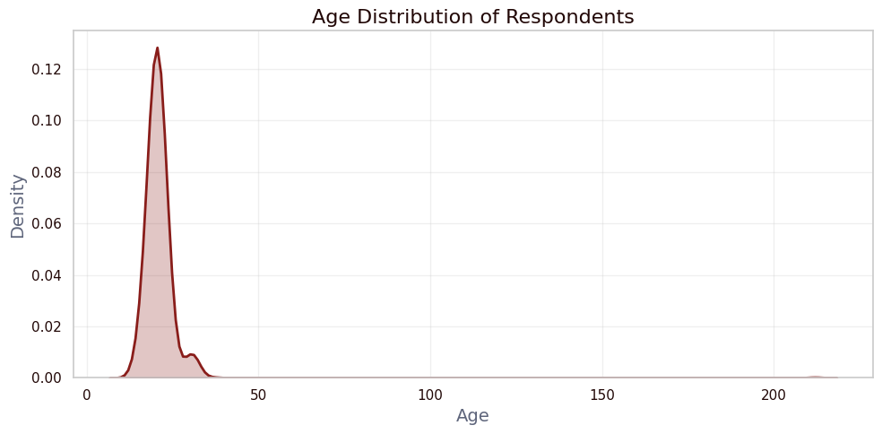

```python
# Age Distribution - KDE plot
plt.figure(figsize=(10, 5))
sns.kdeplot(data['age'], fill=True, color=palette[1], linewidth=2)
plt.title('Age Distribution of Respondents', fontsize=16, color=palette[0])
plt.xlabel('Age', fontsize=14, color=palette[2])
plt.ylabel('Density', fontsize=14, color=palette[2])
plt.xticks(color=palette[0])
plt.yticks(color=palette[0])
plt.grid(alpha=0.3)
plt.tight_layout()
plt.show()
```

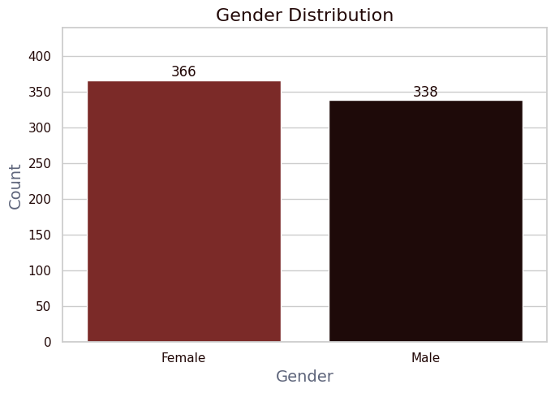

```python
# Gender Count - Bar plot
gender_counts = pd.Series({'Female': data['gender_female'].sum(), 'Male': data['gender_male'].sum()})
plt.figure(figsize=(7, 5))
sns.barplot(x=gender_counts.index, y=gender_counts.values, palette=[palette[1], palette[0]])
plt.title('Gender Distribution', fontsize=16, color=palette[0])
plt.xlabel('Gender', fontsize=14, color=palette[2])
plt.ylabel('Count', fontsize=14, color=palette[2])
plt.xticks(color=palette[0])
plt.yticks(color=palette[0])
for i, val in enumerate(gender_counts.values):
    plt.text(i, val + 5, str(val), ha='center', color=palette[0], fontsize=12)
plt.ylim(0, gender_counts.values.max()*1.2)
plt.tight_layout()
plt.show()
```

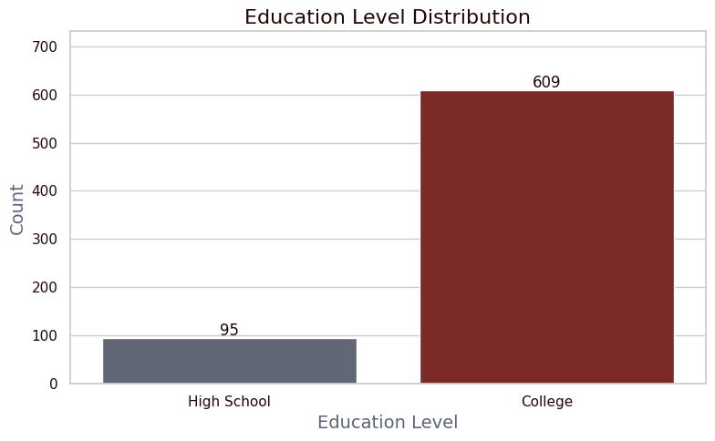

```python
# Education Level Distribution - Count Plot
edu_cols = ['educational_level_high school', 'educational_level_college']
edu_map = {'educational_level_high school': 'High School', 'educational_level_college': 'College'}
edu_counts = {edu_map[col]: data[col].sum() for col in edu_cols}

plt.figure(figsize=(8, 5))
sns.barplot(x=list(edu_counts.keys()), y=list(edu_counts.values()), palette=[palette[2], palette[1]])
plt.title('Education Level Distribution', fontsize=16, color=palette[0])
plt.xlabel('Education Level', fontsize=14, color=palette[2])
plt.ylabel('Count', fontsize=14, color=palette[2])
plt.xticks(color=palette[0])
plt.yticks(color=palette[0])
for i, val in enumerate(edu_counts.values()):
    plt.text(i, val + 5, str(int(val)), ha='center', color=palette[0], fontsize=12)
plt.ylim(0, max(edu_counts.values())*1.2)
plt.tight_layout()
plt.show()
```

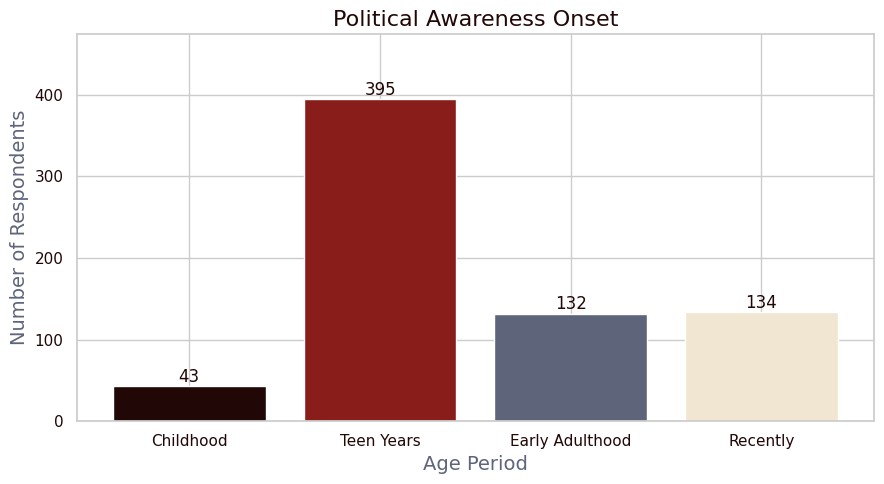

```python
# Political Awareness Onset - Stacked Bar Chart

# Columns indicating political awareness onset
awareness_cols = [
    'age_political_awareness_onset_childhood',
    'age_political_awareness_onset_teen years',
    'age_political_awareness_onset_early adulthood',
    'age_political_awareness_onset_recently'
]

# Rename for readability
awareness_labels = ['Childhood', 'Teen Years', 'Early Adulthood', 'Recently']

awareness_counts = [data[col].sum() for col in awareness_cols]

plt.figure(figsize=(9, 5))
bars = plt.bar(awareness_labels, awareness_counts, color=palette[:4])
plt.title('Political Awareness Onset', fontsize=16, color=palette[0])
plt.xlabel('Age Period', fontsize=14, color=palette[2])
plt.ylabel('Number of Respondents', fontsize=14, color=palette[2])
plt.xticks(color=palette[0])
plt.yticks(color=palette[0])
for i, val in enumerate(awareness_counts):
    plt.text(i, val + 5, str(int(val)), ha='center', color=palette[0], fontsize=12)
plt.ylim(0, max(awareness_counts)*1.2)
plt.tight_layout()
plt.show()
```

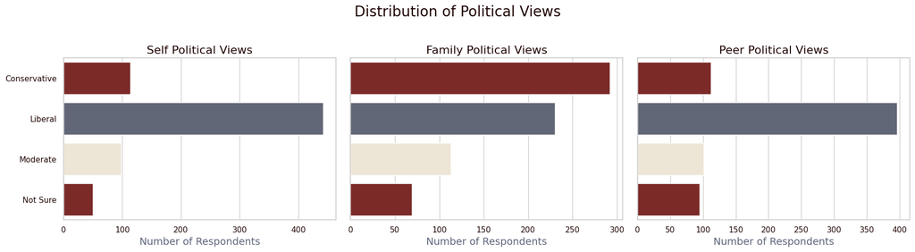

```python
# Helper: Map boolean columns to labels for political views
def extract_view_counts(data, prefix):
    cols = [col for col in data.columns if col.startswith(prefix)]
    labels = [col.replace(prefix + '_', '').replace('_', ' ').title() for col in cols]
    counts = [data[col].sum() for col in cols]
    return labels, counts

# 1. Distribution of Political Views for Self, Family, and Peers
fig, axs = plt.subplots(1, 3, figsize=(18, 5), sharey=True)

for ax, prefix, title in zip(
    axs,
    ['OwnPoliticalView', 'FamilyPoliticalView', 'PeerPoliticalView'],
    ['Self Political Views', 'Family Political Views', 'Peer Political Views']
):
    labels, counts = extract_view_counts(data, prefix)
    sns.barplot(x=counts, y=labels, palette=palette[1:], ax=ax)
    ax.set_title(title, fontsize=16, color=palette[0])
    ax.set_xlabel('Number of Respondents', fontsize=14, color=palette[2])
    ax.set_ylabel('')
    ax.tick_params(colors=palette[0], axis='x')
    ax.tick_params(colors=palette[0], axis='y')

plt.suptitle('Distribution of Political Views', fontsize=20, color=palette[0])
plt.tight_layout(rect=[0, 0, 1, 0.95])
plt.show()
```

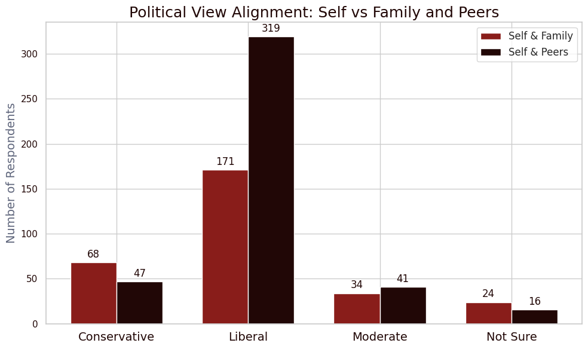

```python
# Alignment between Self and Family / Peers Political Views

# Create simplified alignment columns for comparison
def get_alignment(df, prefix1, prefix2):
    # For each political stance: conservative, liberal, moderate, not sure
    stances = ['conservative', 'liberal', 'moderate', 'not sure']
    align_counts = []
    for stance in stances:
        both_agree = ((df[f'{prefix1}_{stance}']) & (df[f'{prefix2}_{stance}'])).sum()
        align_counts.append(both_agree)
    return stances, align_counts

stances, family_align = get_alignment(data, 'OwnPoliticalView', 'FamilyPoliticalView')
_, peer_align = get_alignment(data, 'OwnPoliticalView', 'PeerPoliticalView')

x = np.arange(len(stances))
width = 0.35

fig, ax = plt.subplots(figsize=(10,6))
bars1 = ax.bar(x - width/2, family_align, width, label='Self & Family', color=palette[1])
bars2 = ax.bar(x + width/2, peer_align, width, label='Self & Peers', color=palette[0])

ax.set_xticks(x)
ax.set_xticklabels([s.title() for s in stances], fontsize=14, color=palette[0])
ax.set_ylabel('Number of Respondents', fontsize=14, color=palette[2])
ax.set_title('Political View Alignment: Self vs Family and Peers', fontsize=18, color=palette[0])
ax.legend(facecolor='white', fontsize=12)
ax.tick_params(colors=palette[0])

# Annotate bars
for bars in [bars1, bars2]:
    for bar in bars:
        height = bar.get_height()
        ax.annotate(f'{height}', xy=(bar.get_x() + bar.get_width()/2, height),
                    xytext=(0,3), textcoords='offset points',
                    ha='center', va='bottom', color=palette[0], fontsize=12)

plt.tight_layout()
plt.show()
```

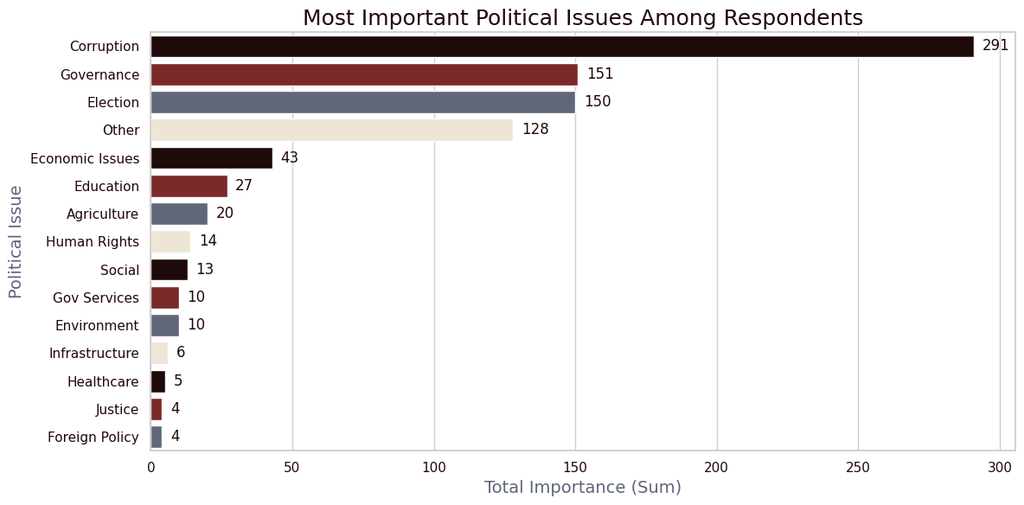

```python
# List of issue columns (integer counts/importance)
issue_cols = [
    'issue_economic_issues', 'issue_governance', 'issue_social', 'issue_environment',
    'issue_education', 'issue_justice', 'issue_election', 'issue_human_rights',
    'issue_other', 'issue_foreign_policy', 'issue_healthcare', 'issue_infrastructure',
    'issue_corruption', 'issue_agriculture', 'issue_gov_services'
]

# 1. Sum total importance per issue and sort descending
issue_sums = data[issue_cols].sum().sort_values(ascending=False)

plt.figure(figsize=(12,6))
sns.barplot(x=issue_sums.values, y=[col.replace('issue_', '').replace('_', ' ').title() for col in issue_sums.index],
            palette=palette[:len(issue_sums)])
plt.title('Most Important Political Issues Among Respondents', fontsize=18, color=palette[0])
plt.xlabel('Total Importance (Sum)', fontsize=14, color=palette[2])
plt.ylabel('Political Issue', fontsize=14, color=palette[2])
plt.xticks(color=palette[0])
plt.yticks(color=palette[0])
for i, val in enumerate(issue_sums.values):
    plt.text(val + max(issue_sums.values)*0.01, i, int(val), color=palette[0], fontsize=12, va='center')
plt.tight_layout()
plt.show()
```

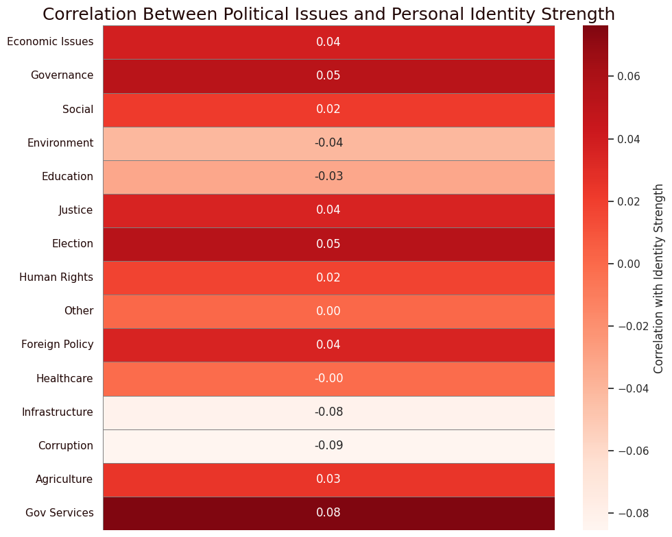

```python
# Correlation heatmap: Issues vs PersonalIdentityStrength
corr_df = data[issue_cols + ['PersonalIndentityStrength']].corr()

plt.figure(figsize=(10,8))
sns.heatmap(corr_df.loc[issue_cols, 'PersonalIndentityStrength'].to_frame(),
            annot=True, cmap='Reds', center=0,
            cbar_kws={'label': 'Correlation with Identity Strength'},
            linewidths=0.5, linecolor='gray', fmt=".2f",
            yticklabels=[col.replace('issue_', '').replace('_', ' ').title() for col in issue_cols])
plt.title('Correlation Between Political Issues and Personal Identity Strength', fontsize=18, color=palette[0])
plt.yticks(rotation=0, color=palette[0])
plt.xticks([], [])
plt.tight_layout()
plt.show()
```

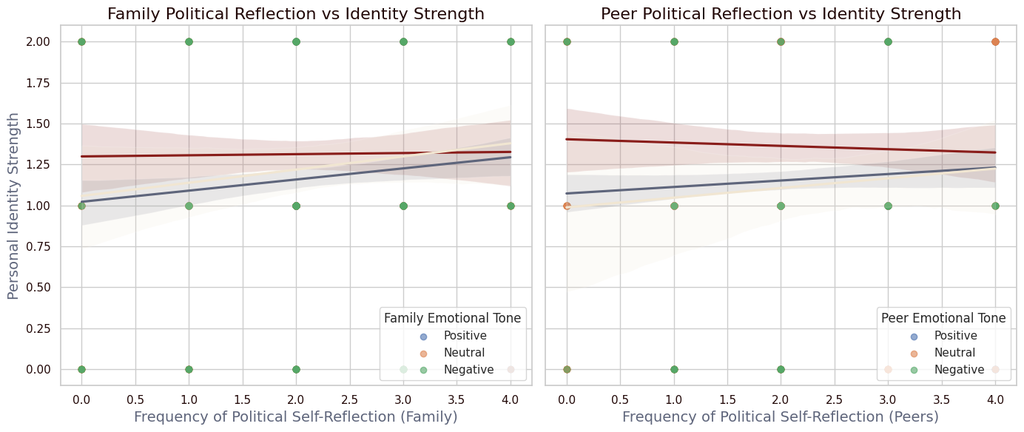

```python
# Prepare dataframe with key columns
df = data.copy()

fig, axs = plt.subplots(1, 2, figsize=(14, 6), sharey=True)

# Family reflection freq vs PersonalIdentityStrength colored by FamilyEmotionalTone (positive, neutral, negative)
family_tones = ['FamilyEmotionalTone_positive', 'FamilyEmotionalTone_neutral', 'FamilyEmotionalTone_negative']
family_tone_labels = ['Positive', 'Neutral', 'Negative']
family_palette = palette[1:4]

for tone, label, color in zip(family_tones, family_tone_labels, family_palette):
    subset = df[df[tone] == True]
    sns.regplot(x='political_self_reflection_freq_family', y='PersonalIndentityStrength',
                data=subset, scatter_kws={'alpha':0.6}, line_kws={'color':color},
                label=label, ax=axs[0], scatter=True)
axs[0].set_title('Family Political Reflection vs Identity Strength', fontsize=16, color=palette[0])
axs[0].set_xlabel('Frequency of Political Self-Reflection (Family)', fontsize=14, color=palette[2])
axs[0].set_ylabel('Personal Identity Strength', fontsize=14, color=palette[2])
axs[0].legend(title='Family Emotional Tone')
axs[0].tick_params(colors=palette[0])

# Peer reflection freq vs PersonalIdentityStrength colored by PeerEmotionalTone
peer_tones = ['PeerEmotionalTone_positive', 'PeerEmotionalTone_neutral', 'PeerEmotionalTone_negative']
peer_palette = palette[1:4]

for tone, label, color in zip(peer_tones, family_tone_labels, peer_palette):
    subset = df[df[tone] == True]
    sns.regplot(x='political_self_reflection_freq_peers', y='PersonalIndentityStrength',
                data=subset, scatter_kws={'alpha':0.6}, line_kws={'color':color},
                label=label, ax=axs[1], scatter=True)
axs[1].set_title('Peer Political Reflection vs Identity Strength', fontsize=16, color=palette[0])
axs[1].set_xlabel('Frequency of Political Self-Reflection (Peers)', fontsize=14, color=palette[2])
axs[1].set_ylabel('')
axs[1].legend(title='Peer Emotional Tone')
axs[1].tick_params(colors=palette[0])

plt.tight_layout()
plt.show()
```

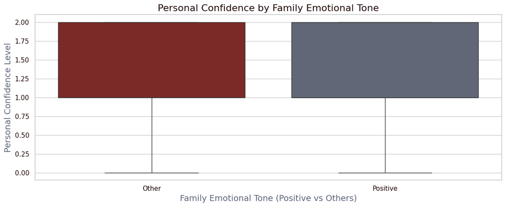

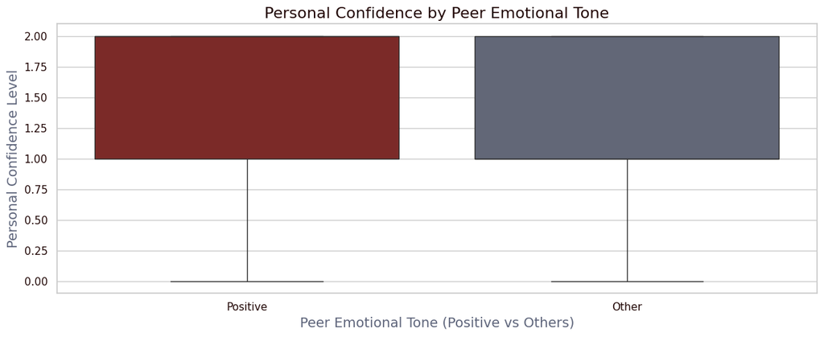

```python
plt.figure(figsize=(12,5))
sns.boxplot(
    x='FamilyEmotionalTone_positive', y='PersonalConfidenceLevel',
    data=data.replace({True:'Positive', False:'Other'}),
    palette=[palette[1], palette[2]]
)
plt.title('Personal Confidence by Family Emotional Tone', fontsize=16, color=palette[0])
plt.xlabel('Family Emotional Tone (Positive vs Others)', fontsize=14, color=palette[2])
plt.ylabel('Personal Confidence Level', fontsize=14, color=palette[2])
plt.xticks(color=palette[0])
plt.yticks(color=palette[0])
plt.tight_layout()
plt.show()

plt.figure(figsize=(12,5))
sns.boxplot(
    x='PeerEmotionalTone_positive', y='PersonalConfidenceLevel',
    data=data.replace({True:'Positive', False:'Other'}),
    palette=[palette[1], palette[2]]
)
plt.title('Personal Confidence by Peer Emotional Tone', fontsize=16, color=palette[0])
plt.xlabel('Peer Emotional Tone (Positive vs Others)', fontsize=14, color=palette[2])
plt.ylabel('Personal Confidence Level', fontsize=14, color=palette[2])
plt.xticks(color=palette[0])
plt.yticks(color=palette[0])
plt.tight_layout()
plt.show()
```

### 4.5 Machine Learning Implementation

```python
# --- DATA PREPARATION ---
X = data_reduced.drop(columns=['Political_Alignment_peers', 'cleaned_issues', 'category',
                               'categories', 'categories_split', 'PoliticalIssues',
                               'Political_Alignment_family'])
y = data_reduced['Political_Alignment_peers']
```

```python
# Split data once (we'll use the same splits for all models)
X_train, X_test, y_train, y_test = train_test_split(X, y, test_size=0.20)
```

```python
# Scale numeric features (important for KNN and SVM)

numeric_cols = X.select_dtypes(include=['float64', 'int64']).columns
scaler = StandardScaler()

X_train[numeric_cols] = scaler.fit_transform(X_train[numeric_cols])
X_test[numeric_cols] = scaler.transform(X_test[numeric_cols])
```

### 4.6 Proportional Chance Criteria (PCC)

```python
# --- PROPORTIONAL CHANCE CRITERION ---
def proportional_chance_criterion(y):
    class_counts = y.value_counts(normalize=True)
    pcc = np.sum(class_counts ** 2)
    print(f"PCC: {pcc:.4f}")
    pcc_threshold = pcc * 1.25
    print(f"PCC × 1.25 threshold: {pcc_threshold:.4f}")
    return pcc_threshold

pcc_125 = proportional_chance_criterion(y)
```

```
PCC: 0.5009
PCC × 1.25 threshold: 0.6261
```

```python
# ---  BASELINE MODELS ---

from sklearn.ensemble import AdaBoostClassifier, GradientBoostingClassifier

models = {
    "KNN": KNeighborsClassifier(),
    "Decision Tree": DecisionTreeClassifier(),
    "Random Forest": RandomForestClassifier(),
    "Logistic Regression": LogisticRegression(max_iter=1000),
    "Linear SVM": LinearSVC(max_iter=10000),
    "AdaBoost": AdaBoostClassifier(),
    "Gradient Boosting": GradientBoostingClassifier()
}
```

```python
def evaluate_model(model, X_train, X_test, y_train, y_test, trials=50):
    train_scores = []
    test_scores = []

    for _ in tqdm(range(trials), desc=f"Evaluating {model.__class__.__name__}"):
        m = clone(model)
        m.fit(X_train, y_train)
        train_pred = m.predict(X_train)
        test_pred = m.predict(X_test)
        train_scores.append(accuracy_score(y_train, train_pred))
        test_scores.append(accuracy_score(y_test, test_pred))

    return {
        'Model': model.__class__.__name__,
        'Mean Train Accuracy': np.mean(train_scores),
        'Mean Test Accuracy': np.mean(test_scores),
        'Overfitting Gap': np.mean(train_scores) - np.mean(test_scores)
    }
```

```python
print("\n--- Baseline Model Evaluation ---")
baseline_results = []
for name, model in models.items():
    baseline_results.append(evaluate_model(model, X_train, X_test, y_train, y_test))

baseline_df = pd.DataFrame(baseline_results)[['Model', 'Mean Train Accuracy', 'Mean Test Accuracy', 'Overfitting Gap']]
baseline_df
```

```
--- Baseline Model Evaluation ---
```

|  | Model | Mean Train Accuracy | Mean Test Accuracy | Overfitting Gap |
| --- | --- | --- | --- | --- |
| 0 | KNeighborsClassifier | 0.809947 | 0.702128 | 0.107819 |
| 1 | DecisionTreeClassifier | 1.000000 | 0.834326 | 0.165674 |
| 2 | RandomForestClassifier | 1.000000 | 0.865532 | 0.134468 |
| 3 | LogisticRegression | 0.813499 | 0.773050 | 0.040449 |
| 4 | LinearSVC | 0.808171 | 0.758865 | 0.049305 |
| 5 | AdaBoostClassifier | 0.802842 | 0.794326 | 0.008516 |
| 6 | GradientBoostingClassifier | 0.964476 | 0.879433 | 0.085043 |

### 4.7 Cross Validation and Hyperparamater Tuning

```python
def robust_evaluate_with_train_score(model, X, y, cv_splits=5, trials=5):
    train_scores = []
    cv_scores = []
    pipe = make_pipeline(StandardScaler(), model)

    for _ in range(trials):
        kf = KFold(n_splits=cv_splits, shuffle=True, random_state=None)
        for train_idx, val_idx in kf.split(X):
            X_train, X_val = X.iloc[train_idx], X.iloc[val_idx]
            y_train, y_val = y.iloc[train_idx], y.iloc[val_idx]

            pipe.fit(X_train, y_train)

            train_pred = pipe.predict(X_train)
            val_pred = pipe.predict(X_val)

            train_scores.append(accuracy_score(y_train, train_pred))
            cv_scores.append(accuracy_score(y_val, val_pred))

    return {
        'Mean Train Accuracy': np.mean(train_scores),
        'Mean CV Accuracy': np.mean(cv_scores),
    }

print("\n--- Cross Validation Results (with train accuracy) ---")
cv_results = {}
for name, model in models.items():
    print(f"Evaluating {name}...")
    cv_results[name] = robust_evaluate_with_train_score(model, X, y)

cv_df = pd.DataFrame.from_dict(cv_results, orient='index')
cv_df
```

```
--- Cross Validation Results (with train accuracy) ---
Evaluating KNN...
Evaluating Decision Tree...
Evaluating Random Forest...
Evaluating Logistic Regression...
Evaluating Linear SVM...
Evaluating AdaBoost...
Evaluating Gradient Boosting...
```

|  | Mean Train Accuracy | Mean CV Accuracy |
| --- | --- | --- |
| KNN | 0.817823 | 0.708809 |
| Decision Tree | 1.000000 | 0.814507 |
| Random Forest | 1.000000 | 0.871044 |
| Logistic Regression | 0.823294 | 0.764725 |
| Linear SVM | 0.821094 | 0.767042 |
| AdaBoost | 0.814632 | 0.776436 |
| Gradient Boosting | 0.956959 | 0.840334 |

```python
param_grids = {
    'Decision Tree': {
        'model__criterion': ['gini', 'entropy'],
        'model__max_depth': [3, 5, 7, 10, None],
        'model__min_samples_split': [2, 5, 10],
        'model__min_samples_leaf': [1, 2, 4],
        'model__max_features': ['sqrt', 'log2', None],
        'model__class_weight': ['balanced', None]
    },
    'Random Forest': {
        'model__n_estimators': [50, 100, 200],
        'model__max_depth': [5, 10, 20, None],
        'model__min_samples_split': [2, 5, 10],
        'model__min_samples_leaf': [1, 2, 4],
        'model__max_features': ['sqrt', 'log2'],
        'model__bootstrap': [True, False],
        'model__class_weight': ['balanced', None]
    },
    'KNN': {
        'model__n_neighbors': [2,3,4,5,7,9,10,15],
        'model__weights': ['uniform', 'distance'],
        'model__p': [1, 2]
    },
    'Linear SVM': {
        'model__C': [0.1, 1, 10],
        'model__penalty': ['l1', 'l2'],
        'model__loss': ['hinge', 'squared_hinge'],
        'model__dual': [False],
        'model__class_weight': ['balanced', None]
    },
    'Logistic Regression': {
        'model__C': [0.1, 1, 10],
        'model__penalty': ['l1', 'l2'],
        'model__solver': ['liblinear', 'saga'],
        'model__class_weight': ['balanced', None]
    },
    'AdaBoost': {
        'model__n_estimators': [50, 100, 200],
        'model__learning_rate': [0.01, 0.1, 0.5, 1],
        'model__algorithm': ['SAMME', 'SAMME.R']
    },
    'Gradient Boosting': {
        'model__n_estimators': [50, 100, 200],
        'model__learning_rate': [0.01, 0.1, 0.2],
        'model__max_depth': [3, 5, 7],
        'model__min_samples_split': [2, 5, 10],
        'model__min_samples_leaf': [1, 2, 4],
        'model__subsample': [0.6, 0.8, 1.0],
        'model__max_features': ['sqrt', 'log2', None]
    }
}
```

```python
def tune_model(model, param_grid, X_train, y_train):
    step_name = model.__class__.__name__.lower()
    param_grid_updated = {}
    for key, val in param_grid.items():
        if key.startswith('model__'):
            new_key = key.replace('model__', f'{step_name}__')
            param_grid_updated[new_key] = val
        else:
            param_grid_updated[key] = val
    pipe = Pipeline([
        ('standardscaler', StandardScaler()),
        (step_name, model)
    ])
    grid = GridSearchCV(pipe, param_grid_updated, cv=5, scoring='accuracy', n_jobs=-1)
    grid.fit(X_train, y_train)  # use only training data here
    print(f"\nBest parameters for {model.__class__.__name__}:")
    print(grid.best_params_)
    return grid.best_estimator_, grid.best_params_
```

```python
best_models = {}
best_params = {}
for name, model in models.items():
    print(f"\n=== Tuning {name} ===")
    best_model, best_param = tune_model(model, param_grids[name], X_train, y_train)  # use train split
    best_models[name] = best_model
    best_params[name] = best_param
```

```
=== Tuning KNN ===

Best parameters for KNeighborsClassifier:
{'kneighborsclassifier__n_neighbors': 3, 'kneighborsclassifier__p': 1, 'kneighborsclassifier__weights': 'distance'}

=== Tuning Decision Tree ===

Best parameters for DecisionTreeClassifier:
{'decisiontreeclassifier__class_weight': None, 'decisiontreeclassifier__criterion': 'gini', 'decisiontreeclassifier__max_depth': 10, 'decisiontreeclassifier__max_features': None, 'decisiontreeclassifier__min_samples_leaf': 2, 'decisiontreeclassifier__min_samples_split': 2}

=== Tuning Random Forest ===

Best parameters for RandomForestClassifier:
{'randomforestclassifier__bootstrap': False, 'randomforestclassifier__class_weight': None, 'randomforestclassifier__max_depth': 20, 'randomforestclassifier__max_features': 'sqrt', 'randomforestclassifier__min_samples_leaf': 1, 'randomforestclassifier__min_samples_split': 2, 'randomforestclassifier__…

=== Tuning Logistic Regression ===

Best parameters for LogisticRegression:
{'logisticregression__C': 1, 'logisticregression__class_weight': None, 'logisticregression__penalty': 'l2', 'logisticregression__solver': 'liblinear'}

=== Tuning Linear SVM ===

Best parameters for LinearSVC:
{'linearsvc__C': 0.1, 'linearsvc__class_weight': 'balanced', 'linearsvc__dual': False, 'linearsvc__loss': 'squared_hinge', 'linearsvc__penalty': 'l2'}

=== Tuning AdaBoost ===

Best parameters for AdaBoostClassifier:
{'adaboostclassifier__algorithm': 'SAMME', 'adaboostclassifier__learning_rate': 1, 'adaboostclassifier__n_estimators': 100}

=== Tuning Gradient Boosting ===

Best parameters for GradientBoostingClassifier:
{'gradientboostingclassifier__learning_rate': 0.1, 'gradientboostingclassifier__max_depth': 7, 'gradientboostingclassifier__max_features': 'log2', 'gradientboostingclassifier__min_samples_leaf': 4, 'gradientboostingclassifier__min_samples_split': 10, 'gradientboostingclassifier__n_estimators': 100, …
```

## 5. Results and Discussion

Since Random Forest or Decision Tree models provide feature importances directly, you can use one of these models to get the top features.

```python
# Use the best Random Forest model (or Decision Tree) to find feature importances
best_rf = best_models['Random Forest']

# Extract feature importances
importances = best_rf.named_steps['randomforestclassifier'].feature_importances_

# Get feature names from X_train (before scaling)
feature_names = X_train.columns

# Create a dataframe of features and their importances
feat_imp_df = pd.DataFrame({'feature': feature_names, 'importance': importances})

# Sort by importance descending and select top 12
top_features = feat_imp_df.sort_values(by='importance', ascending=False).head(12)['feature'].tolist()

print("Top 12 Features:")
print(top_features)
```

```
Top 12 Features:
['ParentApprovalLevel', 'FamilyInfluenceStrength', 'PeerApprovalLevel', 'family_approval_importance_politics', 'PeerDiscussionInterest', 'PeerEngagement', 'age', 'FamilyEngagement', 'importance_fam_political_alignment', 'political_self_reflection_freq_peers', 'PeerInfluenceStrength', 'political_self…
```

Retrain All Models Using Only Top 12 Features and Best Hyperparameters

```python
X_train_top = X_train[top_features]
X_test_top = X_test[top_features]
```

```python
retrained_models = {}
train_accs = {}
test_accs = {}
overfit_gaps = {}

for name, model in models.items():
    print(f"\nRetraining {name} with best hyperparameters on top features...")

    # Extract best params from original tuning
    params = best_params[name]

    # Remove pipeline prefixes
    step_name = model.__class__.__name__.lower()
    model_params = {k.split(f"{step_name}__")[1]: v for k, v in params.items() if k.startswith(f"{step_name}__")}

    # Instantiate model with best params
    model_best = model.__class__(**model_params)

    # Build pipeline with scaler + model
    pipe = Pipeline([
        ('standardscaler', StandardScaler()),
        (step_name, model_best)
    ])

    # Fit on top features only
    pipe.fit(X_train_top, y_train)

    # Predict train and test
    train_pred = pipe.predict(X_train_top)
    test_pred = pipe.predict(X_test_top)

    train_acc = accuracy_score(y_train, train_pred)
    test_acc = accuracy_score(y_test, test_pred)
    overfit_gap = train_acc - test_acc

    print(f"{name} Train Accuracy: {train_acc:.4f}")
    print(f"{name} Test Accuracy: {test_acc:.4f}")
    print(f"{name} Overfitting Gap: {overfit_gap:.4f}")

    retrained_models[name] = pipe
    train_accs[name] = train_acc
    test_accs[name] = test_acc
    overfit_gaps[name] = overfit_gap

# Summary table with Overfitting Gap
results_summary = pd.DataFrame({
    'Model': list(train_accs.keys()),
    'Train Accuracy': list(train_accs.values()),
    'Test Accuracy': list(test_accs.values()),
    'Overfitting Gap': list(overfit_gaps.values())
})

print("\n=== Summary of retrained models with best params on top features ===")
print(results_summary)
```

```
Retraining KNN with best hyperparameters on top features...
KNN Train Accuracy: 0.9982
KNN Test Accuracy: 0.8227
KNN Overfitting Gap: 0.1755

Retraining Decision Tree with best hyperparameters on top features...
Decision Tree Train Accuracy: 0.9307
Decision Tree Test Accuracy: 0.8298
Decision Tree Overfitting Gap: 0.1009

Retraining Random Forest with best hyperparameters on top features...
Random Forest Train Accuracy: 0.9982
Random Forest Test Accuracy: 0.9007
Random Forest Overfitting Gap: 0.0975

Retraining Logistic Regression with best hyperparameters on top features...
Logistic Regression Train Accuracy: 0.7815
Logistic Regression Test Accuracy: 0.7447
Logistic Regression Overfitting Gap: 0.0368

Retraining Linear SVM with best hyperparameters on top features...
Linear SVM Train Accuracy: 0.7815
Linear SVM Test Accuracy: 0.7447
Linear SVM Overfitting Gap: 0.0368

Retraining AdaBoost with best hyperparameters on top features...
AdaBoost Train Accuracy: 0.7957
AdaBoost Test Accuracy: 0.7518
AdaBoost Overfitting Gap: 0.0440

Retraining Gradient Boosting with best hyperparameters on top features...
Gradient Boosting Train Accuracy: 0.9982
Gradient Boosting Test Accuracy: 0.8440
Gradient Boosting Overfitting Gap: 0.1543

=== Summary of retrained models with best params on top features ===
                 Model  Train Accuracy  Test Accuracy  Overfitting Gap
0                  KNN        0.998224       0.822695         0.175529
1        Decision Tree        0.930728       0.829787         0.100941
2        Random Forest        0.998224       0.900709         0.097515
3  Logistic Regression        0.781528       0.744681         0.036847
4           Linear SVM        0.781528       0.744681         0.036847
5             AdaBoost        0.795737       0.751773         0.043964
6    Gradient Boosting        0.998224       0.843972         0.154252
```

### 5.2 SHAP (SHapley Additive exPlanations)

```python
import shap
import warnings
```

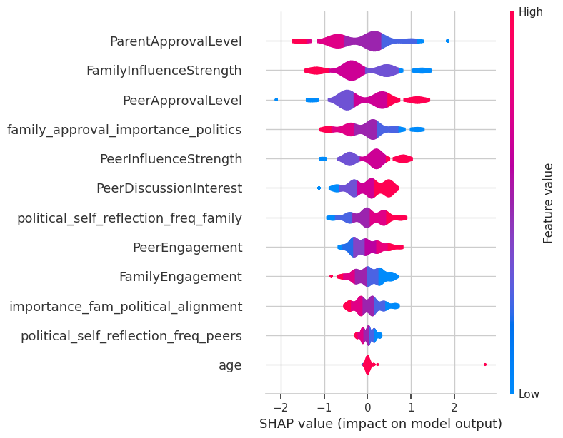

```python
logreg_pipeline = retrained_models['Logistic Regression']
logreg_model = logreg_pipeline.named_steps['logisticregression']

X_explain = X_train_top

explainer = shap.LinearExplainer(logreg_model, X_explain, feature_perturbation="interventional")
shap_values = explainer.shap_values(X_explain)

shap.summary_plot(shap_values, X_explain, plot_type="violin")
```

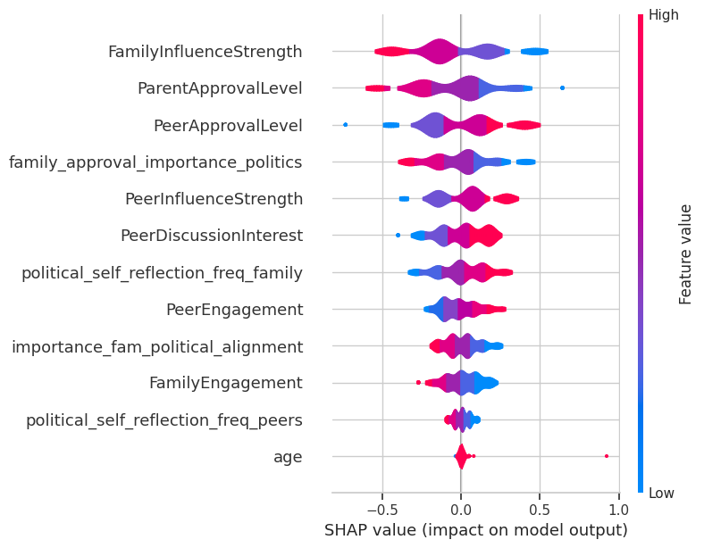

```python
logreg_pipeline = retrained_models['Linear SVM']
logreg_model = logreg_pipeline.named_steps['linearsvc']

X_explain = X_train_top

explainer = shap.LinearExplainer(logreg_model, X_explain, feature_perturbation="interventional")
shap_values = explainer.shap_values(X_explain)

shap.summary_plot(shap_values, X_explain, plot_type="violin")
```

### 5.3 Model Evaluation

```python
from sklearn.metrics import classification_report, confusion_matrix
from matplotlib.colors import LinearSegmentedColormap
```

```
=== Confusion Matrix and Report for KNN ===
              precision    recall  f1-score   support

       False       0.83      0.86      0.84        79
        True       0.81      0.77      0.79        62

    accuracy                           0.82       141
   macro avg       0.82      0.82      0.82       141
weighted avg       0.82      0.82      0.82       141
```

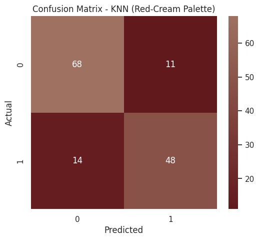

```
=== Confusion Matrix and Report for Decision Tree ===
              precision    recall  f1-score   support

       False       0.83      0.87      0.85        79
        True       0.83      0.77      0.80        62

    accuracy                           0.83       141
   macro avg       0.83      0.82      0.83       141
weighted avg       0.83      0.83      0.83       141
```

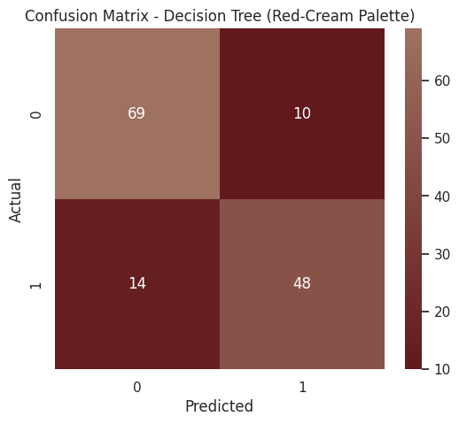

```
=== Confusion Matrix and Report for Random Forest ===
              precision    recall  f1-score   support

       False       0.90      0.92      0.91        79
        True       0.90      0.87      0.89        62

    accuracy                           0.90       141
   macro avg       0.90      0.90      0.90       141
weighted avg       0.90      0.90      0.90       141
```

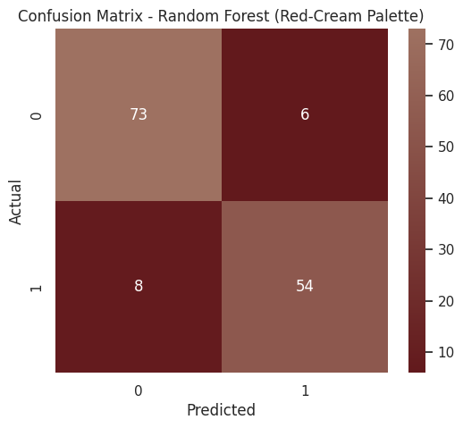

```
=== Confusion Matrix and Report for Logistic Regression ===
              precision    recall  f1-score   support

       False       0.79      0.73      0.76        79
        True       0.69      0.76      0.72        62

    accuracy                           0.74       141
   macro avg       0.74      0.75      0.74       141
weighted avg       0.75      0.74      0.75       141
```

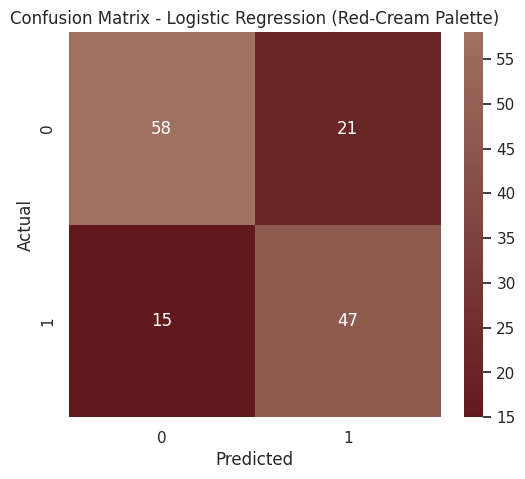

```
=== Confusion Matrix and Report for Linear SVM ===
              precision    recall  f1-score   support

       False       0.79      0.73      0.76        79
        True       0.69      0.76      0.72        62

    accuracy                           0.74       141
   macro avg       0.74      0.75      0.74       141
weighted avg       0.75      0.74      0.75       141
```

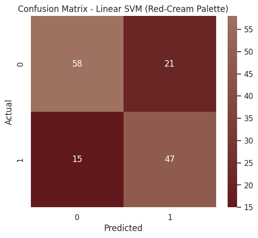

```
=== Confusion Matrix and Report for AdaBoost ===
              precision    recall  f1-score   support

       False       0.83      0.70      0.76        79
        True       0.68      0.82      0.74        62

    accuracy                           0.75       141
   macro avg       0.76      0.76      0.75       141
weighted avg       0.77      0.75      0.75       141
```

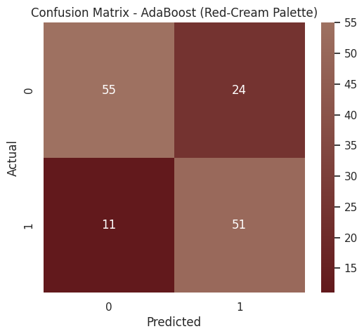

```
=== Confusion Matrix and Report for Gradient Boosting ===
              precision    recall  f1-score   support

       False       0.88      0.84      0.86        79
        True       0.80      0.85      0.83        62

    accuracy                           0.84       141
   macro avg       0.84      0.85      0.84       141
weighted avg       0.85      0.84      0.84       141
```

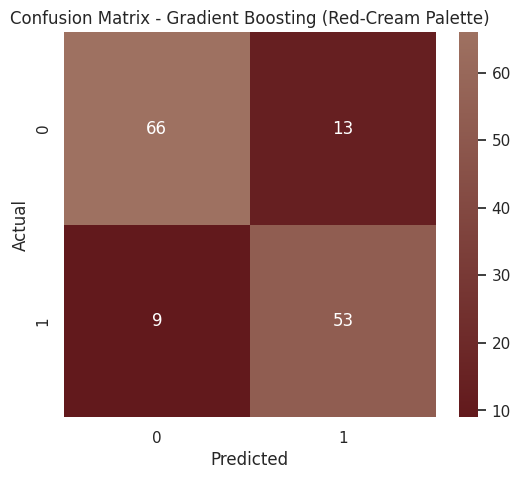

```python
# Define red to cream colormap
red_cream_cmap = LinearSegmentedColormap.from_list("RedCream", ["#62191C", "#9E7161"])

for model_name, model in retrained_models.items():
    print(f"\n=== Confusion Matrix and Report for {model_name} ===")

    # Predict on test data with top features
    y_pred = model.predict(X_test_top)

    # Print classification report
    print(classification_report(y_test, y_pred))

    # Compute confusion matrix
    cm = confusion_matrix(y_test, y_pred)

    # Plot confusion matrix heatmap
    plt.figure(figsize=(6,5))
    sns.heatmap(cm, annot=True, fmt='d', cmap=red_cream_cmap, cbar=True)
    plt.xlabel('Predicted')
    plt.ylabel('Actual')
    plt.title(f'Confusion Matrix - {model_name} (Red-Cream Palette)')
    plt.show()
```

## 6. Conclusion

This study reveals how deeply our political beliefs are shaped by the people around us—especially our family and peers. Rather than forming our political identity alone, we constantly absorb and reflect the views, approval, and pressures from these social groups. The project shows that both family and peer influences are important, but their impact varies for each person.

By exploring how often people talk about politics, how emotionally charged those conversations are, and how much approval or pressure individuals feel, we gain a clearer picture of the social forces shaping political opinions. Understanding whether family or peers have a stronger influence helps us appreciate that political identity is not fixed but a dynamic social process.

This insight is powerful because it highlights that political views are built through relationships and interactions—not just personal opinions or isolated choices. It reminds us that when we engage in political conversations or education, we must consider these social influences to foster critical thinking and independent perspectives.

This project, "Who Told You What to Believe? Deconstructing the Social Blueprint of Political Identity through Machine Learning," successfully demonstrates that political identity formation is a nuanced social process deeply influenced by the interplay of family and peer contexts. By leveraging machine learning classification techniques on comprehensive survey data, we quantitatively uncovered the relative impact of various social and psychological factors in shaping political alignment.

The results reveal that while Random Forest achieves the highest test accuracy (90.07%), models such as Logistic Regression and Linear SVM, despite their lower accuracy (~74.5%), exhibit substantially smaller overfitting gaps (approximately 3.7%), highlighting their robustness and reliability in generalization. This suggests that simpler linear models, although less complex, avoid overfitting and may offer more interpretable insights into the underlying social mechanisms influencing political beliefs.

AdaBoost emerges as a compelling intermediate option, balancing test accuracy (75.2%) with a low overfitting gap (4.4%). Its ensemble boosting mechanism effectively focuses on hard-to-classify instances, capturing subtle social dynamics that linear models might miss while maintaining good generalizability.

The SHAP analysis further confirms that critical features like ParentApprovalLevel, FamilyInfluenceStrength, and PeerApprovalLevel significantly contribute to the models' predictions, emphasizing the complex interdependence of approval and influence from both family and peers. This validates the theoretical foundation that political identity is not built in isolation but constructed through continuous social interaction and negotiation.

Classifying whether family or peer influence predominates is crucial, as it informs our understanding of the socialization process that underpins political behavior and engagement. Identifying these dominant influences can help target political education and critical thinking initiatives tailored to different social contexts, ultimately fostering independent political thought.

### **Hyperparameter Tuning Parameter Grid**

This table shows the hyperparameters and their values during grid search for each model:

| **Model** | **Hyperparameter** | **Values** |
| --- | --- | --- |
| K-Nearest Neighbors | n_neighbors | 3 |
|  | p | 1 |
|  | weights | distance |
| Decision Tree | class_weight | None |
|  | criterion | gini |
|  | max_depth | 10 |
|  | max_features | None |
|  | min_samples_leaf | 2 |
|  | min_samples_split | 2 |
| Random Forest | bootstrap | False |
|  | class_weight | None |
|  | max_depth | 20 |
|  | max_features | sqrt |
|  | min_samples_leaf | 1 |
|  | min_samples_split | 2 |
|  | n_estimators | 50 |
| Logistic Regression | C | 1 |
|  | class_weight | None |
|  | penalty | l2 |
|  | solver | liblinear |
| Linear SVM | C | 0.1 |
|  | class_weight | balanced |
|  | dual | False |
|  | loss | squared_hinge |
|  | penalty | l2 |
| AdaBoost | algorithm | SAMME |
|  | learning_rate | 1 |
|  | n_estimators | 100 |
| Gradient Boosting | learning_rate | 0.1 |
|  | max_depth | 7 |
|  | max_features | log2 |
|  | min_samples_leaf | 4 |
|  | min_samples_split | 10 |
|  | n_estimators | 100 |
|  | subsample | 0.6 |

### **Top 12 Features**

These are the most important features selected based on feature importance scores from the Random Forest model:

[output not shown]

.

## Why This Project is Important

This project addresses a vital gap in political socialization research by quantitatively differentiating family versus peer influence on political identity, which traditional qualitative studies often overlook or treat separately. By integrating multidimensional survey questions that capture frequency, emotional tone, approval importance, social pressure, and reflective engagement, the project validates these variables as key predictors of political alignment.

The survey questions were carefully selected and validated based on theoretical relevance from political socialization, social identity, and group conformity theories. The inclusion of demographic moderators (age, gender, education) adds depth to understanding how individual factors interact with social influence. This rigorous validation ensures the model reflects real-world social dynamics rather than abstract correlations.

## Technical Recommendations

**Model Deployment & Interpretation:**

- Utilize Random Forest for high-accuracy predictive tasks where maximizing classification performance is the priority.
- For interpretability and minimizing overfitting risks, employ Logistic Regression or Linear SVM models, especially when explaining political influence factors to non-technical stakeholders or policymakers.
- Consider AdaBoost as a middle ground for balancing complexity, accuracy, and robustness. Its iterative focusing on misclassified cases could capture nuanced social patterns missed by other models.

**Further Research:**

- Extend the dataset to include longitudinal tracking to observe how family and peer influences evolve over time in political identity development.
- Explore additional social contexts such as media influence, community engagement, and online networks to build a more comprehensive social blueprint.
- Investigate the moderating role of psychological traits like openness, conformity tendency, and critical thinking skills in mediating social influence effects.

**Practical Application:**

- Use these insights to design targeted civic education programs that consider dominant social influences on youth political socialization.
- Encourage family-based dialogues alongside peer group discussions to foster balanced political awareness and critical reflection.
- Promote independent political thought by highlighting how social contexts shape, but do not determine, political identity.

**Why the Survey Questions are Essential & Valid**

- The survey questions capture a broad and relevant spectrum of social and psychological dimensions impacting political alignment:
- Social Influence Variables: Measuring approval levels, emotional tone, discussion interest, and engagement reflects the quality and intensity of political socialization within family and peer groups.
- Reflective Engagement: Questions about political self-reflection frequency highlight internal cognitive processing influenced by social contexts.
- Demographics & Identity Strength: Variables like age, gender, and personal confidence contextualize political identity within developmental and social frameworks.

## Recommendations (Non-Technical)

- **Encourage Open Political Conversations in Families and Peer Groups** Creating spaces where young people can openly discuss politics with family and friends helps them understand different viewpoints and develop their own beliefs. Encouraging respectful dialogue reduces pressure and conflict and supports independent thinking.
- **Support Youth in Reflecting on Social Influences** Helping young people recognize how family and peer opinions shape their views empowers them to critically evaluate these influences. This can be done through workshops, education programs, or community activities that promote self-reflection about political beliefs.
- **Tailor Civic Education to Social Contexts** Since family and peer influences differ among individuals, civic education should be flexible and responsive. Programs can include family engagement activities for those strongly influenced by home, and peer-led discussions for those more influenced by friends.
- **Promote Awareness that Political Identity is Socially Constructed** Sharing the idea that political beliefs grow out of social relationships helps reduce polarization and promotes empathy. Understanding this can encourage people to listen more carefully to others and appreciate the social background behind differing political views.

## Connecting the Project to Its Real-World Importance & Deeper Understanding

If someone asks: *“Isn’t everyone entitled to their own choices, especially in voting or politics? Why should we care if peers or family influence them? What’s the strength of this project?”*

**Individual choice exists, but it’s rarely made in isolation.** No person makes decisions — political or otherwise — in a vacuum. Our beliefs and votes are shaped by conversations, experiences, and values passed down or shared by family, friends, and social circles. The question is not whether influence exists — it clearly does — but how much and in what ways it operates. Our project quantifies this influence for the first time in a data-driven, objective way.

**Machine learning reveals patterns invisible to the naked eye.** Traditional surveys or anecdotal evidence often miss the complex interplay of multiple social factors. Our model captures these subtle influences across many variables, revealing which relationships are strongest. It goes beyond simple assumptions and tells us which social influences matter most, and under what conditions.

**Why is that relevant? Because understanding influence empowers choice.** Knowing that family or peers sway political opinions isn’t about denying personal freedom — it’s about recognizing the real context in which choices are made. With that knowledge, we can design better educational programs, promote critical thinking, or encourage exposure to diverse viewpoints — all helping individuals make more informed and independent decisions.

*After classification — what then? What deeper insight do we gain?*

- Why do these influences hold more weight? Is it trust, shared values, or lack of alternative information sources?
- Are there underlying societal or cultural reasons that reinforce certain social circles over others?

Ultimately, this project bridges data and democracy. It reminds us that “freedom of choice” is also about freedom informed by awareness. Machine learning here is a tool to illuminate the social dynamics that shape democracy itself — so that stakeholders, whether policymakers, educators, or citizens, can engage with the political process more consciously and effectively.

## 7. References

**Lundberg, S. M., & Lee, S.-I. (2017).** A Unified Approach to Interpreting Model Predictions. Advances in Neural Information Processing Systems (NeurIPS), 30, 4765–4774.

**Ribeiro, M. T., Singh, S., & Guestrin, C. (2016).** "Why Should I Trust You?": Explaining the Predictions of Any Classifier. Proceedings of the 22nd ACM SIGKDD International Conference on Knowledge Discovery and Data Mining, 1135–1144.

**Bartels, L. M. (2008).** The Study of Electoral Behavior. In The Oxford Handbook of American Elections and Political Behavior.

**Huckfeldt, R., & Sprague, J. (1995)**. Citizens, Politics, and Social Communication: Information and Influence in an Election Campaign. Cambridge University Press.

**Gelman, A., & Hill, J. (2007).** Data Analysis Using Regression and Multilevel/Hierarchical Models. Cambridge University Press.

**Breiman, L. (2001).** Random Forests. Machine Learning, 45(1), 5–32.

**Shmueli, G. (2010).** To Explain or to Predict? Statistical Science, 25(3), 289–310.

**Pearl, J. (2009).** Causality: Models, Reasoning, and Inference. Cambridge University Press.

**Dolezal, M., & Schröder, M. (2017).** Social Influence and Political Attitudes: Evidence from Experimental Data. Journal of Experimental Political Science, 4(2), 145–159.

**Iyengar, S., & Simon, A. (2000).** New Perspectives and Evidence on Political Communication and Campaign Effects. Annual Review of Psychology, 51, 149–169.

**Hastie, T., Tibshirani, R., & Friedman, J. (2009).** The Elements of Statistical Learning: Data Mining, Inference, and Prediction. Springer.

**Lazer, D., et al. (2018).** The Science of Fake News. Science, 359(6380), 1094–1096.

**Asch, S. E. (1955).** Opinions and social pressure. Scientific American, 193(5), 31-35.

**Beck, P. A., & Jennings, M. K. (1991).** Family traditions, political periods, and the development of partisan orientations. The Journal of Politics, 53(3), 742-763.

**Jennings, M. K., & Niemi, R. G. (1968).** The transmission of political values from parent to child. American Political Science Review, 62(1), 169-184.

**Tajfel, H., & Turner, J. C. (1979).** An integrative theory of intergroup conflict. In The social psychology of intergroup relations (pp. 33-47). Monterey, CA: Brooks/Cole.